# Введение в гражданское право

## Евгений Алексеевич Суханов

[figure not shown]

- Заместитель председателя Совета при Президенте РФ по кодификации и совершенствованию гражданского законодательства; член совета по совершенствованию законодательства под председательством заместителя Председателя Государственной Думы РФ; член научно-консультативных советов при Верховном Суде РФ, при Высшем Арбитражном Суде РФ и при Генеральной прокуратуре РФ.

## Вадим Анатольевич Белов

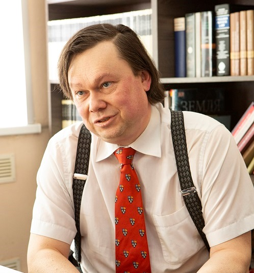

- Российский правовед, доктор юридических наук (2004), профессор кафедры коммерческого права и основ правоведения Московского государственного университета (2011); член редакционного совета журнала «Коммерческое право», основатель и ответственный редактор серии юридических трудов «Научное наследие»; главный эксперт по правовым вопросам при генеральной дирекции ОАО «Северсталь».

## Сергей Аркадьевич Степанов

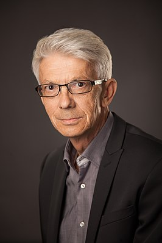

- 19 февраля 1955, Ленинград — 12 ноября 2019, Екатеринбург — советский и российский учёный-правовед, доктор юридических наук, профессор, директор Института частного права (г. Екатеринбург).
- Под редакцией профессора С. А. Степанова выпущены Комментарий к Гражданскому кодексу Российской Федерации, Комментарий к Семейному кодексу Российской Федерации, учебник «Гражданское право» (совместно с членом-корреспондентом РАН, профессором С. С. Алексеевым).

## Рашад Афатович Курбанов

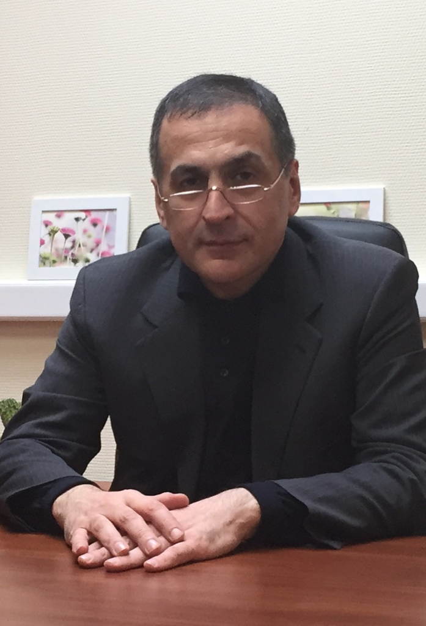

- Российский учёный-правовед, юрист, эксперт в области гражданского, предпринимательского и международного права. Заведующий кафедрой гражданско-правовых дисциплин Российского экономического университета им. Г. В. Плеханова, заведующий кафедрой правовых основ экономической деятельности ИЗСП при Правительстве РФ, руководитель Научно-исследовательского института правовых исследований и региональной интеграции и Научной школы «Экономико-правовые основы евразийской интеграции» РЭУ им. Г. В. Плеханова.

## Право

## Понятие права

Право – система общеобязательных правил поведения, устанавливаемых государством и охраняемых принудительной силой государства от нарушения.

- Материальное право – совокупность норм, определяющих поведение физических и юридических лиц.
- Процессуальное право – совокупность норм, определяющих порядок функционирования судебных органов, защиты субъективных нарушенных прав.

## Понятие частного права

## Деление права на частное и публичное

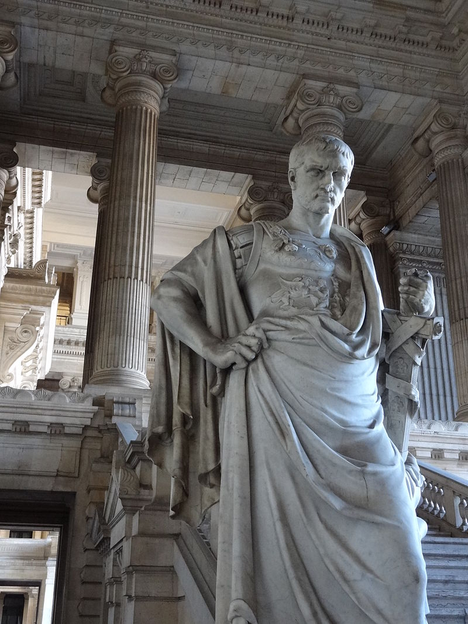

> Публичное право есть то, которое относится к положению римского государства, частное — к пользе отдельных лиц.

Домиций Ульпиан

## Частное и публичное право

| Частное право: | Публичное право: |
| --- | --- |
| Состав участников может быть любым (физические и юридические лица, публичные образования); | Обязательным участником правоотношения является публично-правовое образование (его органы); |
| Интересы отдельных (частных) лиц – частные имущественные и личные неимущественные отношения; | Государственные (муниципальные), общественные интересы – публичные отношения; |
| В основном диспозитивные нормы права с использованием императивных; | Как правило, императивные нормы права; |
| Отношения основаны на юридическом равенстве сторон, свободе выбора и договоре, имущественной независимости. | Отношения основаны на юридическом неравенстве, подчинении одной стороны другой. |
| Принуждение возможно исключительно по решению суда. | Принуждение в силу полномочий органа. Может быть обжаловано. |

## Отрасли публичного и частного права

Отрасль права – элемент системы права, представляющий собой совокупность норм права, регулирующих качественно однородную группу общественных отношений.

| Частное | Публичное |
| --- | --- |
| Гражданское право | Конституционное право |
| Предпринимательское право | Административное право |
| Семейное право | Уголовное право |
| Международное частное право | Арбитражное процессуальное право |

> ! Частно-публичное право: подготовить информацию к семинару.

## Гражданское право

## Подходы к пониманию гражданского права

Как отрасль права:

> Система правовых норм, которые регулируют отношения имущественно самостоятельных, юридически равных частных лиц.

Как отрасль законодательства:

> Совокупность законов и иных нормативных правовых актов, содержащих нормы гражданского права.

## Подходы к пониманию гражданского права

Как правовая наука:

> Определенным образом систематизированная совокупность знаний о гражданско-правовом регулировании общественных отношений; свойствах и закономерностях его функционирования и развития; способах достижения его эффективности; средствах получения новых знаний, необходимых для дальнейшего совершенствования гражданского права.

Как учебная дисциплина:

> Обобщенные и систематизированные сведения о гражданско-правовых явлениях, понятиях, категориях, изучение которых позволяет понимать не только содержание, но и смысл гражданско-правового регулирования, грамотно оценивать и анализировать достоинства и недостатки действующей гражданско-правовой регламентации.

## Определение гражданского права

Гражданское право является отраслью частного права, составляет его основу.

Гражданское право – система правовых норм, регулирующих имущественные и личные неимущественные отношения, основанные на автономии воли, имущественной самостоятельности и юридическом равенстве участников. В некоторых случаях предусмотренных в норме, отношения основаны на властном подчинении одной стороны другой для защиты неотчуждаемых прав и других нематериальных благ.

## Предмет гражданского права (ст. 2 ГК РФ)

Предмет гражданского права составляют имущественные и личные неимущественные отношения, в том числе корпоративные отношения, предпринимательские отношения.

*Имущественные отношения* – это отношения, возникающие по поводу имущества – материальных благ, имеющих экономическую форму товара.

*Личные неимущественные отношения* – отношения, возникающие по поводу нематериальных благ, которые не имеют стоимостных характеристик. Не участвуют в гражданском обороте, но подлежат правовой защите.

*Корпоративные отношения* – правоотношения, возникающие в связи с созданием юридических лиц и участием в их деятельности или управлением ими.

*Предпринимательские отношения* – отношения между лицами, осуществляющими предпринимательскую деятельность, или с их участием.

## Гражданско-правовой метод регулирования

Метод правового регулирования – совокупность приемов, способов и средств, с помощью права воздействующих на общественные отношения.

Суть гражданско-правового метода:

1. Юридическое равенство сторон, имущественная самостоятельность, автономия воли;
2. Горизонтальные связи;
3. Правонаделение;
4. Дозволение;
5. Координация.

## Признаки гражданско-правового метода

1. Характер правового положения участников регулируемых отношений;
2. Особенности возникновения правовых связей между участниками этих отношений;
3. Специфика разрешения возникающих конфликтов;
4. Особенности мер принудительного воздействия на правонарушителей.

## Функции гражданского права

Регулятивная функция заключается в предоставлении участникам гражданских правоотношений возможностей их самоорганизации, саморегулирования. Гражданкое право содержит минимальное количество необходимых запретов и максимум возможных дозволений.

Охранительная функция имеет целью защиту имущественных интересов участников гражданского оборота. Она реализуется путем восстановления нарушенных прав либо компенсации причиненных потерпевшим убытков (ст. 12 ГК).

## Принципы граджанского права

1. Принцип юридического равенства участников гражданско-правовых отношений;

2. Принцип неприкосновенности собственности (ч. 3 ст. 35 К РФ);

3. Принцип свободы договора, в том числе установления субъектами своих прав и обязанностей на основе договора;

4. Принцип недопустимости произвольного вмешательства кого-либо в частные дела;

5. Принцип беспрепятственного осуществления гражданских прав;

## Принципы граджанского права

6. Принцип обеспечения восстановления нарушенных прав и их судебной защиты (ст. 12 ГК РФ);

7. Принцип приобретения и осуществления субъектами своих гражданских прав своей волей и в своем интересе;

8. Принцип добросовестности участников гражданских правоотношений при установлении, осуществлении и защите гражданских прав и при исполнении гражданских обязанностей (п. 3 ст. 1 ГК РФ);

9. Принцип запрета злоупотребления правом (шикана, ст. 10 ГК РФ);

10. Принцип свободы перемещения товаров, услуг и финансовых средств на всей территории РФ.

## Система гражданского права

Внутреннее строение данной отрасли права, единство входящих в нее взаимосвязанных подотраслей и институтов.

- Общая часть:
  - о понятии и принципах гражданского права;
  - о субъектах гражданского права (участниках гражданских правоотношений);
  - об объектах гражданских правоотношений;
  - о возникновении, изменении и прекращении гражданских правоотношений;
  - об осуществлении и защите гражданских прав;
  - о сроках в гражданском праве,
  - некоторые другие правила общего порядка, применимые ко всем гражданским правоотношениям.

## Система гражданского права

- Особенная часть:
  1. вещное право;
  2. обязательственное право:
     - Общая часть;
     - договорное право;
     - внедоговорные (правоохранительные) обязательства.
  3. права на результаты интеллектуальной деятельности и средства индивидуализации (интеллектуальные права);
  4. наследственное право;
  5. гражданско-правовое регулирование и защита личных неимущественных благ.

## Спасибо за внимание